# Chapter 3

Last update: 16/02/2025

### Use Graph

1. We can save graphics through code or graphical user interface. To save graphics through code, place drawing statements between statements that open the target graphics device and statements that close the target graphics device. Here is an example.

```r
pdf("3_1.pdf")
  attach(mtcars)
  plot(wt, mpg)
  abline(lm(mpg~wt))
  title("Regression of MPG on Weight")
  detach(mtcars)
dev.off()
```

2. Function **x11()** without any parameter can be used to create a new graphic window.
3. Only one device is the ‘active’ device: this is the device in which all graphics operations occur. There is a *null device* which is always open but is really a placeholder. Devices are associated with a name (e.g., “X11” or “postscript”) and a number in the range 1 to 63. The null device is always device 1. Once a device has been opened the null device is not considered as a possible active device. There is a list of open devices, and this is considered as a circular list not including the null device. **dev.next()** and **dev.prev()** select the next open device in the appropriate direction, unless no device is open. **dev.off()** shuts down the specified (by default the current) device. If the current device is shut down and any other devices are open, the next open device is made current. It is an error to attempt to shut down device 1. **graphics.off()** shuts down all open graphics devices. Normal termination of a session runs the internal equivalent of graphics.off(). **dev.set()** makes the specified device the active device. If there is no device with that number, it is equivalent to *dev.next()*. If which = 1 it opens a new device and selects that. **dev.list()** returns the numbers of all open devices, except device 1, the null device. This is a numeric vector with a names attribute giving the device names, or NULL is there is no open device. Here is an example.

```r
x11()
plot(1:10)
x11()
plot(rnorm(10))
dev.set(dev.prev())
abline(0, 1)
dev.set(dev.next())
abline(h = 0, col = "gray")
dev.set(dev.prev())
dev.off(); dev.off()
```

### A Simple Example

Patients’ responses to five dose levels of two drugs

| dose | response_to_drugA | response_to_drugB |
| --- | --- | --- |
| 20 | 16 | 15 |
| 30 | 20 | 18 |
| 40 | 27 | 25 |
| 45 | 40 | 31 |
| 60 | 60 | 40 |

Use the codes below to import the data.

```r
dose <- c(20, 30, 40, 45, 60)
drugA <- c(16, 20, 27, 40, 60)
drugB <- c(15, 18, 25, 31, 40)
```

Use the codes below to create a graph describing correlation between dose of drugA and responses.

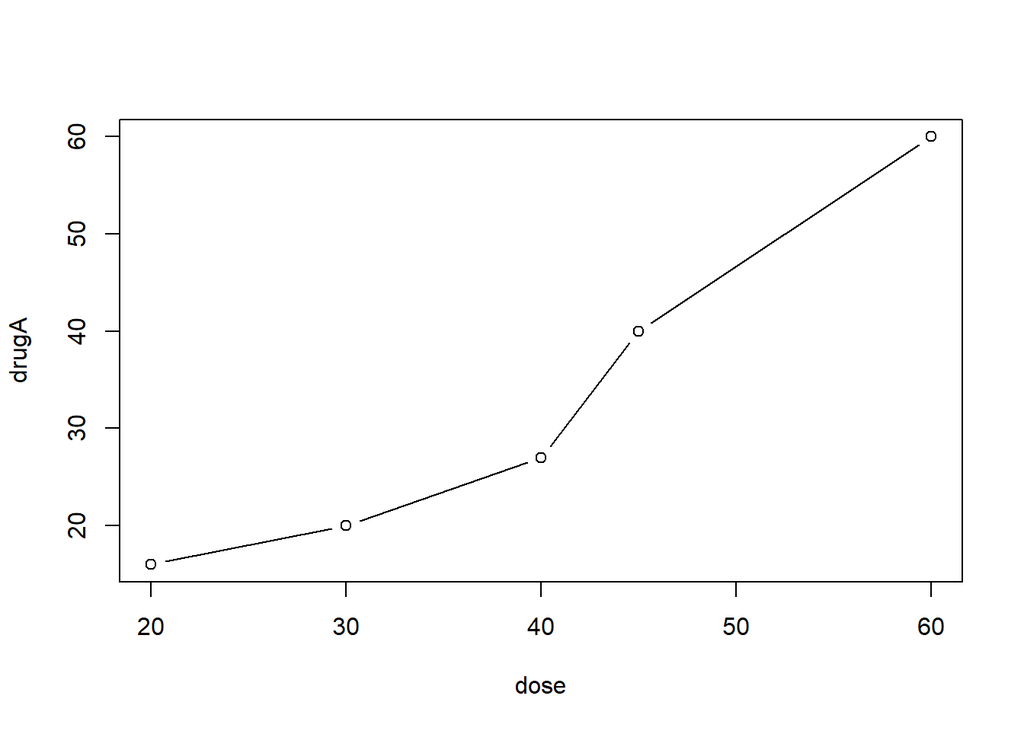

```r
plot(dose, drugA, type = "b")
```

4. **plot()** is a generic function in R that plots objects. Here, *plot(x, y, type = “b”)* puts x in horizontal axis and y in vertical axis, paint point set (x, y), then link them with lines. Option *type = “b”* indicates painting points and lines. What’s more, *“p”* for points, *“l”* for lines, *“c”* for empty points joined by lines, *“o”* for overplotted points and lines, *“s”* for stair steps and *“h”* for histogram-like vertical lines, *“n”* for not produce any points or lines. We may talk about other attributes later.

### Graphics Parameters

We can customize many features of a graph by modifying options called graph parameters(font, color, axis, label). One way to do this is to specify these options via the function **par()**. Parameter values set in this way will remain in effect until the session ends unless they are modified again. Its syntax is **par(optionname = value, optionname = value, …)** . Call *par()* without parameter will generate a list contains current graphic parameter settings. Add parameter **no.readonly = TRUE** can create a modifiable current graphic parameter settings list.  
Here is an example.

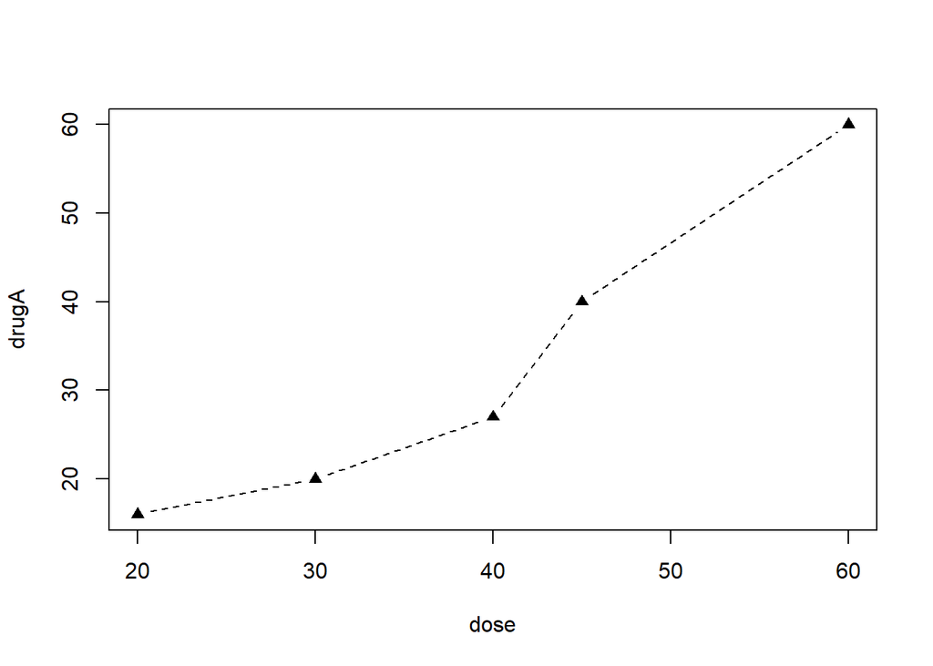

```r
opar <- par(no.readonly = TRUE)
par(lty = 2, pch = 17) # Equal to par(lty = 2); par(pch = 17)
plot(dose, drugA, type = "b")
```

```r
par(opar)
```

The first statement above copies the current graphics parameter settings. The second statement changes the default line type to a dashed line and the default point symbol to a solid triangle. Finally, we draw the graph and restore the original settings.  
Another way to set graphic parameters is to provide key-value pairs *optionname = value* directly to senior graphic functions. But this way only take effect in this graph, and not all parameters are available for all specific senior graphic functions.  
Now, we are going to talk about many graphic parameters.

#### Symbols and Lines

Here are some parameters showed below.

Parameters for specifying symbol and line type

| parameter | description |
| --- | --- |
| pch | Specifies the symbol to use when plotting points. |
| cex | Specifies the symbol size. `cex` is a number indicating the amount by which plotting symbols should be scaled relative to the default.(default = 1) |
| lty | Specifies the line type. |
| lwd | Specifies the line width. `lwd` is expressed relative to the default. (default = 1) |

Option *pch =* is used to specify the symbols when printing points, belows are some possible values.

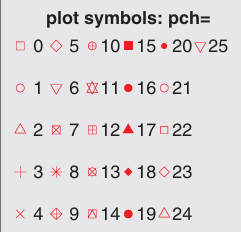

Plotting symbols specified with the pch parameter

For symbols 21~25, we can also specify the border color(col = ) and fill color(bg = ).  
The option *lty =* can be used to specify the wanted line type.

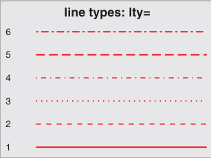

Line types specified with the lty parameter

Here is an example.

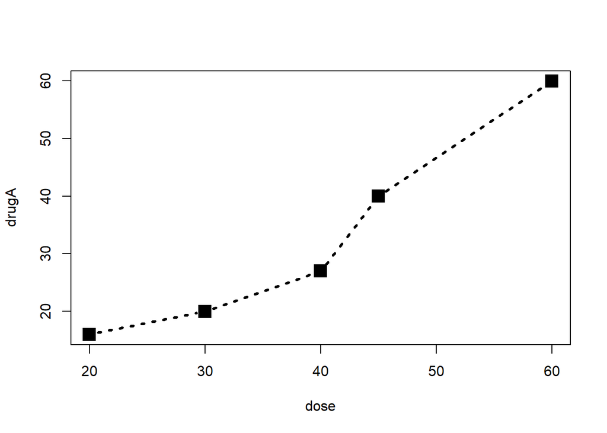

Modify line type, line width, point symbol, symbol size

```r
plot(dose, drugA, type = "b", lty = 3, lwd = 3, pch = 15, cex = 2)
```